# Finite sample inference for stratified samples

2021-09-18

# Background

The goal of this notebook is to investigate a proposal for nonparametric finite-sample (conservative) hypothesis tests of the population mean using stratified samples from the population. This is an extension of ideas developed in [Wendell and Schmee 1996](https://www.tandfonline.com/doi/abs/10.1080/01621459.1996.10476950), [ESI](https://github.com/pbstark/Strat), and [SUITE](https://arxiv.org/abs/1809.04235).

### Optimization for conservative stratified inference

Suppose we have a sampling frame $\mathcal{P}$, which may be discrete or continuous. A uniform random draw from $\mathcal{P}$ is denoted $X_i$, with mean $\mathbb{E}[X_i] = \mu$. We assume that every $X_i$ is bounded in the interval $[0,1]$. The sampling frame is broken into $K$ strata: $\mathcal{P}_1,...,\mathcal{P}_K$, which form a partition of $\mathcal{P}$. Each stratum has an associated relative size $\boldsymbol{a} = [a_1,...,a_K]^T$, which is fixed and known. For example, in a discrete population $a_k$ is the number of units in stratum $\mathcal{P}_k$ divided by the number of units in $\mathcal{P}$. In a continuous, spatial population it could be the area or volume in stratum $k$ divided by the total area or volume. Let $\mu_0$ be the hypothesized mean of $\mathcal{P}$, so that the overall null hypothesis is $H_0: \mu = \mu_0$. The tests must be conducted within individual strata, but the overall null does not specify a single hypothesized null mean for each strata. Instead, the overall null specifies a of null hypotheses within each strata. Let $\boldsymbol{\mu_0} = [\mu_{01},...,\mu_{0K}]^T$ be the vector of stratum-specific means. We can reject the overall null only if we can reject the set of null-hypotheses:
$$\bigcap_{k=1}^K \{a_k \mu_k = \mu_{0k} \} ~~\mbox{for all}~~\boldsymbol{\mu_0}~~\mbox{such that}~~ \boldsymbol{a}^T \boldsymbol{\mu_0} = \mu_0.$$
Note that $\boldsymbol{a}^T \boldsymbol{\mu_0} = \mu_0$ defines a hyperplane in $\mathbb{R}^K$. Pick a particular $\boldsymbol{\mu_0}$ on the hyperplane. If we can get valid $p$-values for the individual null hypotheses by randomly sampling within strata, then we can use Fisher’s combining function to form a new test statistic with known distribution. Specifically, let $p_1(\mu_{01}),...,p_K(\mu_{0K})$ be the individual within stratum $p$-values for a specific $\boldsymbol{\mu_0}$. Fisher’s combining function is:
$$F(\boldsymbol{\mu_0}) = - 2 \sum_{k=1}^K \log(p_k(\mu_{0k})).$$
The $p$-values are independent of each other under random sampling within strata, so under the null hypothesis $F(\boldsymbol{\mu_0})$ follows a $\chi^2_{2K}$ distribution for any fixed $\boldsymbol{\mu_0}$. If we wish to reject every intersection test along the hyperplane defined by $\boldsymbol{a}^T \boldsymbol{\mu_0} = \mu_0$ at level $\alpha$, it suffices to find the maximum combined $p$-value along this hyperplane and check whether it is below $\alpha$. The $p$-value is maximized when $F(\boldsymbol{\mu_0})$ is minimized. The entire setup can thus be written as an optimization problem:

$$\begin{align*}
\min_{\boldsymbol{\mu_0}}& -2 \sum_{k=1}^K \log(p_k(\mu_{0k}))\\
&\mbox{s.t.}\\
&\boldsymbol{a}^T \boldsymbol{\mu_0} = \mu_0\\
&\boldsymbol{\mu_0} \in [0,1]^K
\end{align*}$$
If each of the log $p$-values is concave or linear, then the optimum can be attained quickly for pretty much any $K$ or $n$.

### Exponential Supermartingales

where $\lambda_k \in [0,1)$ is a tuning parameter, $V_{i k}$ is some form of accumulating empirical variance computed in stratum $k$, and $\psi$ is a function particular to the choice of $V_{i k}$.

The overall objective function is thus:

$$\begin{align*}
-2 \sum_{k=1}^K \log p_k(\mu_{0k}) &=
-2 \sum_{k=1}^K \left \{ 0 \wedge \sum_{i=1}^{n_k} \left [ \psi(\lambda_{ik}) V_{i k} - \lambda_{ik} (X_{ik} - \mu_{0k}) \right ] \right \},\\
\end{align*}$$

which is polyhedral. Polyhedral objectives with linear constraints are a linear program and can be quickly solved by introducing slack variables. The code below includes the function `get_stratified_pvalue()` which runs this LP for either empirical Bernstein or Hoeffding bounds. These choices affect $\lambda_{ik}$ and $\psi()$. Either are valid for a [0,1] valued population, but the empirical Bernstein bound adapts to the variance of the strata, which makes it more useful for stratifications that are intended to reduce heterogeneity in the population.

### Hedged Martingales

Now, $\log(x)$ is quasi-convex because non-decreasing functions are quasi-convex (see [Greenberg and Pierskalla, 1971](https://www.jstor.org/stable/169178?seq=1#metadata_info_tab_contents) for rules). Further, $1 + \lambda_{ik} (X_{ik} - \mu_{0k})$ is affine (also quasi-convex), so the terms $\log(1 + \lambda_{ik} (X_{ik} - \mu_{0k}))$ are quasi-convex. The maximum of quasi-convex functions is quasi-convex, so $\max \left \{ 0 , \log \left ( 1 + \lambda_{ik} (X_{ik} - \mu_{0k}) \right ) \right \}$ (without the sum inside) is quasi-convex. Unlike convex functions, the non-negative linear combination of quasi-convex functions is not necessarily quasi-convex. This is a sticking point.

```r
source("stratified_functions.R")
```

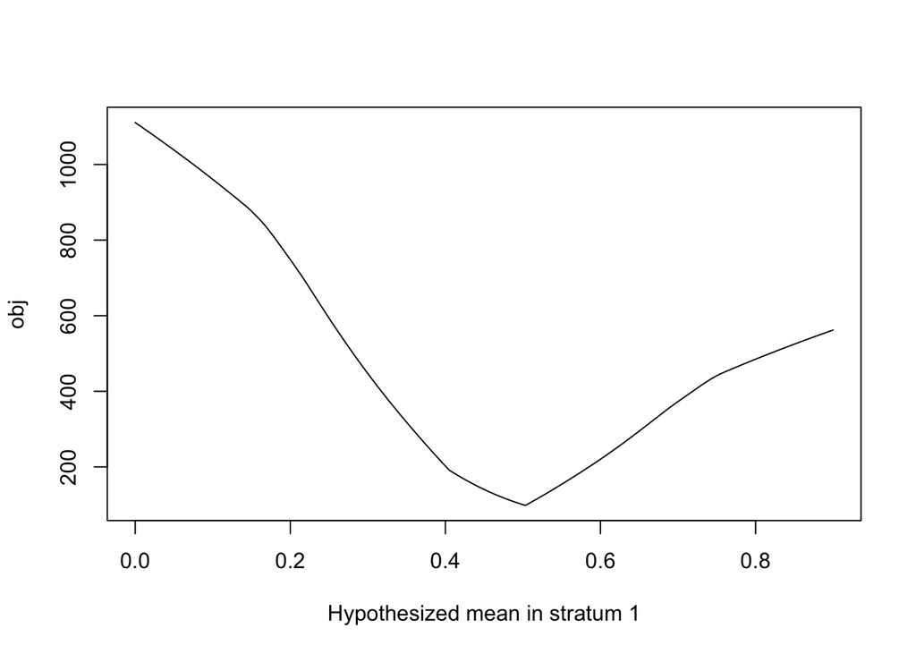

```r
#plot the (one-dimensional) objective function for hedged martingales with 2 strata
#get data
population <- c(rbeta(n = 500, 100, 50), rbeta(n = 500, 100, 50))
population <- population - mean(population) + .5
mu_0 <- .45
n <- c(600,600)
strata = c(rep(1,500), rep(2, 500))
strata_names <- unique(strata)
  strata_sizes <- as.numeric(table(strata))
  K <- length(strata_names)
  a <- prop.table(table(strata))
  statistics_strata <- list()
  for(k in 1:K){
    statistics_strata[[k]] <- get_statistics(population[strata == strata_names[k]], n = n[k], method = "hedged")
  }
lambda_k <- statistics_strata %>%
  map(function(x){x$lambda}) %>%
  reduce(c)
Y <- statistics_strata %>%
  map(function(x){x$Y}) %>%
  reduce(c)

mu_grid <- seq(0,mu_0/a[1],length.out=1000)
obj <- rep(NA, length(mu_grid))
for(i in 1:length(obj)){
  mu_01 <- mu_grid[i]
  mu_02 <- (mu_0 - a[1] * mu_01) / a[2]
  obj[i] <- 2 * max(0, sum(log(1 + pmin(statistics_strata[[1]]$lambda, .75/mu_01) * (statistics_strata[[1]]$Y - mu_01)))) + max(0, sum(log(1 + pmin(statistics_strata[[2]]$lambda, .75/mu_02) * (statistics_strata[[2]]$Y - mu_02))))
}
plot(obj ~ mu_grid, type = 'l', xlab = "Hypothesized mean in stratum 1")
```

### The Beta-Binomial PPM

Prior-posterior martingales (PPMs) can be used for sequential inference if the data comes from a known likelihood. Bayesian posteriors divided by their prior yield martingales when the data have the appropriate distribution. An example is when the data $X_{ik}$ are binomial, which is how data are distributed within strata under stratified simple random sampling with replacement (SRSWR; without replacement, they are hypergeometric). These are closely related to KMART, which was shown in the appendix of https://arxiv.org/pdf/2008.08536.pdf. Following the notation in [Waudby-Smith and Ramdas, 2021](https://arxiv.org/pdf/2006.04347.pdf), take the posterior distribution of $\mu_{0k}$ after $n_k$ draws from stratum $k$ to be $\pi_{n_k}(\mu_{0k})$ under the prior $\pi_{0}(\mu_{0k})$ (the prior could vary by strata and in some cases this might be desirable, but we ignore this in the notation for now). The p-value for stratum $k$ is the ratio of these two densities:

$$p_k(\mu_{0k}) = \frac{\pi_{n_k}(\mu_{0k})}{\pi_{0}(\mu_{0k})}$$

Assuming a binomial likelhood and beta prior with prior shape parameters $\alpha$ and $\beta$, the posterior is also a Beta distribution. Let $Y_k = \sum_{i=1}^{n_k} X_{ik}$ be the total number of 1s in an SRSWR of size $n_k$ from stratum $k$. The within-stratum p-value is

$$p_k(\mu_{0k}) = \min\bigg \{1, \frac{\mbox{Beta}(\mu_{0k} | \alpha + Y_k, \beta + n_k - Y_k )}{\mbox{Beta}(\mu_{0k} | \alpha , \beta )} \bigg \}$$

The Beta distribution is an exponential family with the form:

$$\mbox{Beta}(\mu_{0k} | \alpha , \beta ) = \frac{1}{\mu_{0k}(1-\mu_{0k})} \exp \bigg \{ \alpha \log (\mu_{0k}) + \beta \log (1- \mu_{0k}) - \log\Gamma(\alpha) - \log\Gamma(\beta) + \log\Gamma(\alpha + \beta) \bigg \}$$

where $\Gamma()$ is the Gamma function. Therefore, taking the prior-posterior ratio, the p-value is given by:

$$p_k(\mu_{0k}) = \min \bigg \{ 1, \exp \big \{ Y_k \log(\mu_{0k}) + (n_k - Y_k) \log(1 - \mu_{0k}) - C_k \big \} \bigg \}$$
where $C_k$ is the combined log-partion which is constant in $\mu_0k$:
$$C_k = \log\Gamma(\alpha) + \log\Gamma(\beta) + \log\Gamma(\alpha + Y_k) + \log\Gamma(\beta + n_k - Y_k) - \log\Gamma(\alpha + \beta) - \log\Gamma(\alpha + \beta + n_k)$$

The log-pvalues are:

$$\log p_k(\mu_{0k}) = \min \bigg \{0, ~~Y_k \log(\mu_{0k}) + (n_k - Y_k) \log(1 - \mu_{0k}) - C_k \bigg \}$$

and the overall objective is:

$$-2 \sum_{k=1}^K \log p_k(\mu_{0k}) = -2 \sum_{k=1}^K \min \bigg \{0, ~~Y_k \log(\mu_{0k}) + (n_k - Y_k) \log(1 - \mu_{0k}) - C_k \bigg \}$$

The term $Y_k \log(\mu_{0k}) + (n_k - Y_k) \log(1 - \mu_{0k})$ is always negative, so the min with 0 could be ignored, except that the log-partition $C$ can be negative or positive.

It’s not immediately clear to me whether the objective is convex due to the min with 0. However, I believe it is conservative to ignore the min with 0, in which case the objective becomes:

$$-2 \sum_{k=1}^K \log \tilde{p}_k(\mu_{0k}) = -2 \sum_{k=1}^K ~~Y_k \log(\mu_{0k}) + (n_k - Y_k) \log(1 - \mu_{0k}) - C_k$$

The Lagrangian for the constrained optimization problem is:

$$\mathcal{L}(\boldsymbol{\mu_0}, \lambda) = -2 \sum_{k=1}^K \Big [Y_k \log(\mu_{0k}) + (n_k - Y_k) \log(1 - \mu_{0k}) - C_k \Big ] - \lambda \left (\sum_{k=1}^K a_k \mu_{0k} - \mu_0 \right )$$

The partials of $\mathcal{L}$ are:

$$\begin{align*}
\frac{\partial \mathcal{L}}{\partial \mu_{0k}} &= -2 [Y_k / \mu_{0k} + (n_k - Y_k)/(1-\mu_{0k})] - \lambda a_k \\
\frac{\partial \mathcal{L}}{\partial \lambda} &= \sum_{k=1}^K a_k \mu_{0k} - \mu_0
\end{align*}$$

We can optimize the Lagrangian numerically.

### KMART and PPM

I have seen the approach based on Kaplan’s martingale (KMART) to be sharper than the Beta-Binomial PPM in past simulations. KMART is written up in the [Stark 2020](https://arxiv.org/pdf/1911.10035.pdf). KMART is essentially a mixture version of the betting martingale presented in [Waudby-Smith and Ramdas, 2021](https://arxiv.org/pdf/2010.09686.pdf), the Hedged version of which is itself similar in flavor to the empirical Bernstein exponential supermartingale. It also bears a very close resemblance to the Beta-Binomial PPM, a fact originally noted in [Huang et al, 2021](https://arxiv.org/pdf/2008.08536.pdf).

The KMART p-value for sampling with replacement is the minimum of 1 and:

$$\left [ \int_0^1 \prod_{i=1}^{n_k} \left ( 1 + \gamma \left [\frac{X_{ik}}{\mu_{0k}} - 1 \right ] \right ) d\gamma \right ]^{-1}$$
To see the equivalence with the mixture betting martingales, set $\lambda = \gamma/\mu_{0k}$ to get:

$$\int_0^1 \prod_{i=1}^{n_k} \left ( 1 + \frac{\gamma}{\mu_{0k}} \left (X_{ik} - \mu_{0k} \right) \right ) d\gamma = \int_0^{1/\mu_{0k}} \prod_{i=1}^{n_k} \left ( 1 + \lambda \left (X_{ik} - \mu_{0k} \right) \right ) d\lambda.$$

The second term here is the integral limit of the ``Grid Kelly" betting martingale presented in [Waudby-Smith and Ramdas, 2021](https://arxiv.org/pdf/2010.09686.pdf), which approximates the integral by a Reimann sum. Both Grid Kelly and the original formulation of KMART integrate against uniform weights.

[Huang et al, 2021](https://arxiv.org/pdf/2008.08536.pdf) show that KMART is very similar to the Beta-Binomial PPM, and can use any Beta prior as a weighting function for $\lambda$. KMART uses a truncated beta distribution as the mixing distribution for the alternative. Specifically, let $B(\cdot,\cdot)$ be the Beta function, let $F_0(\mu_{0k})$ be the CDF of the beta prior before truncation, and $F_{n_k}(\mu_{0k})$ be the corresponding conjugate posterior with the untruncated prior after seeing $n_k$ observations. The KMART p-value can be written as the minimum of 1 with:

$$\frac{1}{2} \times \mu_{0k}^{n_k} + \frac{1}{2} \times \frac{\mbox{B}( \alpha + Y_k, \beta + n_k - Y_k )}{\mbox{B}(\alpha , \beta)} \times \frac{1 - F_{n_k}(\mu_{0k})}{1-F_0(\mu_{0k})}$$

```r
source("stratified_functions.R")
```

### Binary populations: ballot polling without invalid votes

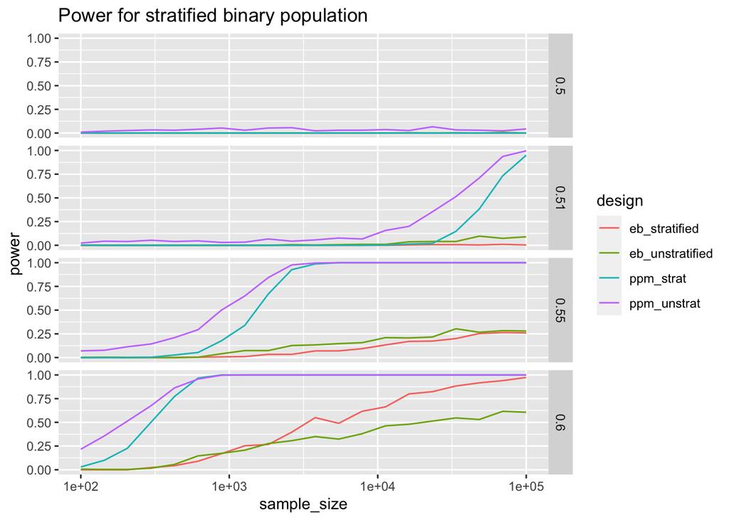

```r
B <- 300
n_grid <- round(10^seq(2, 5, length.out = 20))
#rounds to nearest even integer
n_grid <- ceiling(n_grid) - ceiling(n_grid) %% 2
true_mean <- c(0.5, 0.51, 0.55, 0.6)
power_ppm_unstrat <- matrix(NA, nrow = length(n_grid), ncol = length(true_mean))
power_ppm_strat <- matrix(NA, nrow = length(n_grid), ncol = length(true_mean))
power_eb_unstrat <- matrix(NA, nrow = length(n_grid), ncol = length(true_mean))
power_eb_strat <- matrix(NA, nrow = length(n_grid), ncol = length(true_mean))
for(j in 1:length(true_mean)){
  #population is stratified so first 500 are half the mean of second 500 values
  stratum_1 <- c(rep(1, 1000 * true_mean[j]/2), rep(0, 1000 * (1 - true_mean[j]/2)))
  stratum_2 <- c(rep(1, 1000 * 3*true_mean[j]/2), rep(0, 1000 * (1 - 3*true_mean[j]/2)))
  binary_population <- c(stratum_1, stratum_2)
  for(i in 1:length(n_grid)){
    replicates_ppm_unstrat <- replicate(n = B, beta_binomial_ppm(population = sample(binary_population, size = n_grid[i], replace = TRUE), mu_0 = 0.5, prior_alpha = 1, prior_beta = 1, last = TRUE))
    replicates_ppm_strat <- replicate(n = B, get_stratified_pvalue(population = binary_population, strata = c(rep(1,length(stratum_1)), rep(2, length(stratum_2))), mu_0 = 0.5, n = c(n_grid[i]/2,n_grid[i]/2), method = "beta-binomial"))
    replicates_eb_unstrat <- replicate(n = B, get_stratified_pvalue(population = binary_population, strata = rep(1,length(binary_population)), mu_0 = 0.5, n = n_grid[i], method = "empirical_bernstein"))
    replicates_eb_strat <- replicate(n = B, get_stratified_pvalue(population = binary_population, strata = c(rep(1,length(stratum_1)), rep(2, length(stratum_2))), mu_0 = 0.5, n = c(n_grid[i]/2,n_grid[i]/2), method = "empirical_bernstein"))
    power_ppm_unstrat[i,j] <- mean(replicates_ppm_unstrat < .05)
    power_ppm_strat[i,j] <- mean(replicates_ppm_strat < .05)
    power_eb_unstrat[i,j] <- mean(replicates_eb_unstrat < .05)
    power_eb_strat[i,j] <- mean(replicates_eb_strat < .05)
  }
}

colnames(power_ppm_unstrat) <- paste("true_mean_", true_mean, sep = "")
colnames(power_ppm_strat) <- paste("true_mean_", true_mean, sep = "")
colnames(power_eb_strat) <- paste("true_mean_", true_mean, sep = "")
colnames(power_eb_unstrat) <- paste("true_mean_", true_mean, sep = "")

power_frame_binary <- data.frame("power_eb_stratified" = power_eb_strat, "power_eb_unstratified" = power_eb_unstrat, "power_ppm_unstrat" = power_ppm_unstrat, "power_ppm_strat" = power_ppm_strat, "sample_size" = n_grid) %>%
  pivot_longer(cols = starts_with("power"), names_to = "design", values_to = "power", names_prefix = "power_") %>%
  separate(design, into = c("design","true_mean"), sep = ".true_mean_")
  #separate(design, into = c("martingale", "design"), sep = "_")
ggplot(power_frame_binary, aes(x = sample_size, y = power, color = design)) +
  ggtitle("Power for stratified binary population") +
  geom_line() +
  scale_x_log10() +
  facet_grid(true_mean ~ .)
```

### 3-point distributions: ballot-polling with invalid votes

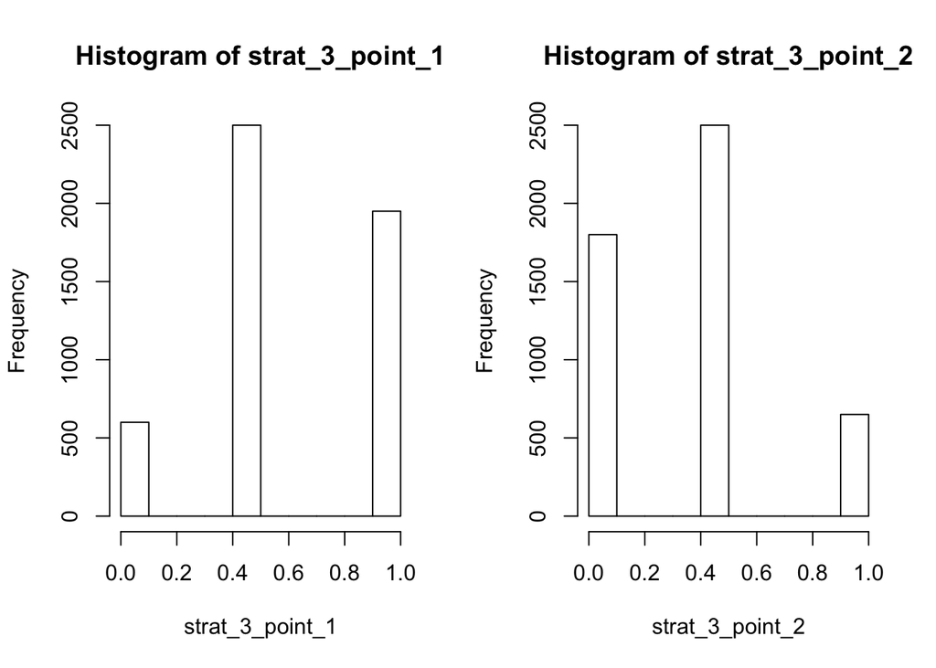

```r
B <- 300
n_grid <- round(10^seq(2, 5, length.out = 10))
n_grid <- ceiling(n_grid) - ceiling(n_grid) %% 2
true_mean <- c(0.5, 0.51, 0.55, 0.6)
power_ppm_unstrat <- matrix(NA, nrow = length(n_grid), ncol = length(true_mean))
power_ppm_strat <- matrix(NA, nrow = length(n_grid), ncol = length(true_mean))
power_eb_unstrat <- matrix(NA, nrow = length(n_grid), ncol = length(true_mean))
power_eb_strat <- matrix(NA, nrow = length(n_grid), ncol = length(true_mean))

#histogram of the 3 point distributions
strat_3_point_1 <- c(rep(0, 2500 * 1/2 * (1.5 - 2 * true_mean[2])), rep(1/2, 2500), rep(1, 2500 * 3/2 * (2 * true_mean[2] - 1/2)))
strat_3_point_2 <- c(rep(0, 2500 * 3/2 * (1.5 - 2 * true_mean[2])), rep(1/2, 2500), rep(1, 2500 * 1/2 * (2 * true_mean[2] - 1/2)))
par(mfrow = c(1,2))
hist(strat_3_point_1)
hist(strat_3_point_2)
```

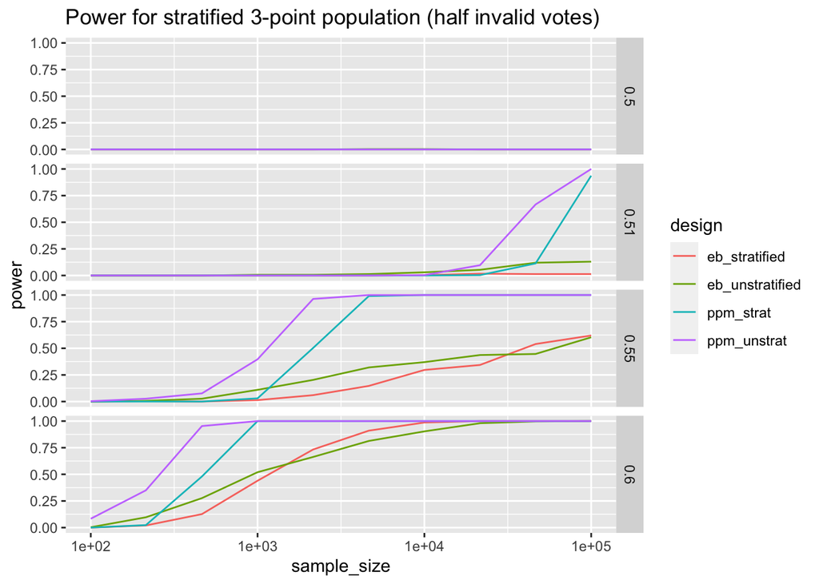

```r
par(mfrow = c(1,1))


#loop over sample size (n_grid) and true population mean (true_mean)
for(j in 1:length(true_mean)){
  #exactly half invalid votes, unstratified population
  unstrat_3_point <- c(rep(0, 5000 * (1.5 - 2 * true_mean[j])), rep(1/2, 5000), rep(1, 5000 * (2 * true_mean[j] - 1/2)))
  #stratified 3 point population
  strat_3_point_1 <- c(rep(0, 2500 * 1/2 * (1.5 - 2 * true_mean[j])), rep(1/2, 2500), rep(1, 2500 * 3/2 * (2 * true_mean[j] - 1/2)))
  strat_3_point_2 <- c(rep(0, 2500 * 3/2 * (1.5 - 2 * true_mean[j])), rep(1/2, 2500), rep(1, 2500 * 1/2 * (2 * true_mean[j] - 1/2)))
  strat_3_point <- c(strat_3_point_1, strat_3_point_2)

  for(i in 1:length(n_grid)){
    replicates_ppm_unstrat <- replicate(n = B, beta_binomial_ppm(population = sample(strat_3_point, size = n_grid[i], replace = TRUE), mu_0 = 0.5, prior_alpha = 1, prior_beta = 1, last = TRUE))
    replicates_ppm_strat <- replicate(n = B, get_stratified_pvalue(population = strat_3_point, strata = c(rep(1,length(strat_3_point_1)), rep(2, length(strat_3_point_2))), mu_0 = 0.5, n = c(n_grid[i]/2,n_grid[i]/2), method = "beta-binomial"))
    replicates_eb_unstrat <- replicate(n = B, get_stratified_pvalue(population = strat_3_point, strata = rep(1,length(strat_3_point)), mu_0 = 0.5, n = n_grid[i], method = "empirical_bernstein"))
    replicates_eb_strat <- replicate(n = B, get_stratified_pvalue(population = strat_3_point, strata = c(rep(1,length(strat_3_point_1)), rep(2, length(strat_3_point_2))), mu_0 = 0.5, n = c(n_grid[i]/2,n_grid[i]/2), method = "empirical_bernstein"))
    power_ppm_unstrat[i,j] <- mean(replicates_ppm_unstrat < .05)
    power_ppm_strat[i,j] <- mean(replicates_ppm_strat < .05)
    power_eb_unstrat[i,j] <- mean(replicates_eb_unstrat < .05)
    power_eb_strat[i,j] <- mean(replicates_eb_strat < .05)
  }
}


colnames(power_ppm_unstrat) <- paste("true_mean_", true_mean, sep = "")
colnames(power_ppm_strat) <- paste("true_mean_", true_mean, sep = "")
colnames(power_eb_strat) <- paste("true_mean_", true_mean, sep = "")
colnames(power_eb_unstrat) <- paste("true_mean_", true_mean, sep = "")

power_frame_3_point <- data.frame("power_eb_stratified" = power_eb_strat, "power_eb_unstratified" = power_eb_unstrat, "power_ppm_unstrat" = power_ppm_unstrat, "power_ppm_strat" = power_ppm_strat, "sample_size" = n_grid) %>%
  pivot_longer(cols = starts_with("power"), names_to = "design", values_to = "power", names_prefix = "power_") %>%
  separate(design, into = c("design","true_mean"), sep = ".true_mean_")
  #separate(design, into = c("martingale", "design"), sep = "_")
ggplot(power_frame_3_point, aes(x = sample_size, y = power, color = design)) +
  ggtitle("Power for stratified 3-point population (half invalid votes)") +
  geom_line() +
  scale_x_log10() +
  facet_grid(true_mean ~ .)
```

### Comparison audits

In a comparison audit, hand-marked paper ballots are compared by hand to machine interpretations of the ballots, called cast vote records (CVRs). [Stark, 2019](https://arxiv.org/pdf/1911.10035.pdf) shows how comparison audits can be reduced to a one-sample problem. Every ballot in stratum $k$ has an unknown number $x_{ik} \leq u$, which is how much that ballot overstates the votes for the winner. Usually $u$ is known because a machine cannot err more than a certain amount in it’s interpretation. A one-vote overstatement occurs when the CVR records a vote for the winner, but the manual inspection reveals an invalid vote. A two-vote overstatement is when the machine interpreted a vote for the loser as a vote for the winner. An assorter $A(\cdot)$ maps each ballot or CVR for a ballot to $[0,u]$, depending on the nature of the contest. We will take $u=1$, which corresponds to a plurality contest. Let $c_{ik}$ denotes the CVR for ballot $i$ in stratum $k$ and $b_{ik}$ the corresponding true paper ballot. In an audit of a two-candidate race with invalid votes, the assorter returns $A(c_{ik}) = 0$ if the CVR shows a vote for the reported loser, $A(c_{ik}) = 1/2$ if the CVR shows an invalid vote, and $A(c_{ik}) = 1$ if the CVR shows a vote for the reported winner. Likewise for an assorter applied to the true ballot. The overstatement error is denoted $\omega_{ik} = A(c_{ik}) - A(b_{ik})$. Note that $\omega_{ik} \in [0,1]$ in this case. The stratum mean of $\omega_{ik}$ is $\bar{\omega}_k = \frac{1}{N_k} \sum_{i=1}^{N_k} \omega_{ik}$ and the population mean is $\bar{\omega} = \frac{1}{K} \sum_{k=1}^K \frac{1}{N_k} \sum_{i=1}^{N_k} \omega_{ik} = \sum_{k=1}^K a_k \bar{\omega}_k$. Similarly, the reported mean is $\bar{A}^c = \frac{1}{K} \sum_{k=1}^K \frac{1}{N_k}\sum_{i=1}^{N_k} A(c_{ik}) = \sum_{k=1}^K a_k \bar{A}^c_k$ and the reported assorter margin is $v = 2 \bar{A}^c - 1$. Define each ballot to have the value:

$$b_{ik} = \frac{1 - \omega_{ik} }{2 - v} \in [0, 1/(2-v)].$$
Let $\mu = \frac{1}{K} \sum_{k=1}^K \frac{1}{N_k} \sum_{i =1}^{N_k} b_{ik}$. The reported winner really won if $\mu > 1/2$, so we wish to test the null $H_0: \mu \leq \frac{1}{2}$.

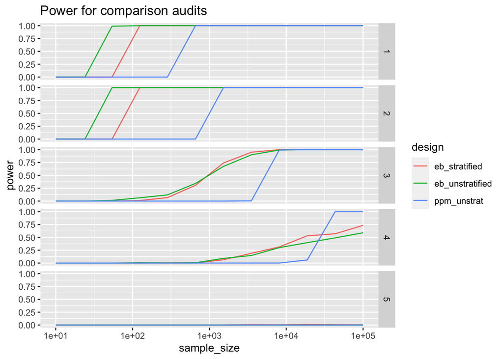

```r
#no invalid votes
reported_tallies <- c(rep(0, 5000), rep(1,5000), rep(0, 2500), rep(1, 7500))

#CVR is correct in first instance and understates the margin. CVR is exactly correct in second. CVR overstates in third and 4th while outcome is correct, CVR is wrong in 5th AND the reported outcome is wrong.
#all are 2 vote overstatements (vote for loser recorded as vote for winner)
hand_tallies <- rbind(
  c(rep(0, 5000), rep(1,5000), rep(0, 2000), rep(1, 8000)),
  c(rep(0, 5000), rep(1,5000), rep(0, 2500), rep(1, 7500)),
  c(rep(0, 5000), rep(1,5000), rep(0, 4000), rep(1, 6000)),
  c(rep(0, 5000), rep(1,5000), rep(0, 4500), rep(1, 5500)),
  c(rep(0, 5000), rep(1,5000), rep(0, 5000), rep(1, 5000))
)
v <- 2 * mean(reported_tallies) - 1
B <- 300
n_grid <- 10^seq(1, 5, length.out = 12)
n_grid <- ceiling(n_grid) - ceiling(n_grid) %% 2
power_ppm_unstrat <- matrix(NA, nrow = length(n_grid), ncol = nrow(hand_tallies))
power_eb_unstrat <- matrix(NA, nrow = length(n_grid), ncol = nrow(hand_tallies))
power_eb_strat <- matrix(NA, nrow = length(n_grid), ncol = nrow(hand_tallies))

for(j in 1:nrow(hand_tallies)){
  omegas <- reported_tallies - hand_tallies[j,]
  pop <- (1 - omegas) / 2


  for(i in 1:length(n_grid)){
    #by keeping the population bounded on [0,1] and testing instead mu_0 = 0.5*(2-v), we get a much sharper bound with PPM.
    #As with ballot-polling, only one-vote overstatements are actually going to degrade its performance because they are in the interior.
    #However... these simulations do not consider the possibility of understatements. I believe it is conservative to count understatements as votes for the winner.
    #If we allow actual 1 and 2 vote understatements, need to divide population by 2 to make it bounded on [0,1].
    #This would probably make variance adaptive bounds better in general, because the modal value is probably 0.5 (the CVR is correct).
    #The mean to be tested is 0.25 * (2-v)
    replicates_ppm_unstrat <- replicate(n = B, beta_binomial_ppm(population = sample(pop, size = n_grid[i], replace = TRUE), mu_0 = 0.25 * (2-v), prior_alpha = 1, prior_beta = 1, last = TRUE))
    replicates_eb_unstrat <- replicate(n = B, get_stratified_pvalue(population = pop, strata = rep(1,20000), mu_0 = 0.25 * (2-v), n = n_grid[i], method = "empirical_bernstein"))
    replicates_eb_strat <- replicate(n = B, get_stratified_pvalue(population = pop, strata = c(rep(1,10000), rep(2, 10000)), mu_0 = 0.25 * (2-v), n = c(n_grid[i]/2,n_grid[i]/2), method = "empirical_bernstein"))
    power_ppm_unstrat[i,j] <- mean(replicates_ppm_unstrat < .05)
    power_eb_unstrat[i,j] <- mean(replicates_eb_unstrat < .05)
    power_eb_strat[i,j] <- mean(replicates_eb_strat < .05)
  }
}
power_frame_comparison <- data.frame("power_eb_stratified" = power_eb_strat, "power_eb_unstratified" = power_eb_unstrat, "power_ppm_unstrat" = power_ppm_unstrat,  "sample_size" = n_grid) %>%
  pivot_longer(cols = starts_with("power"), names_to = "design", values_to = "power", names_prefix = "power_") %>%
  separate(design, into = c("design","scenario"), sep = "\\.")
ggplot(power_frame_comparison, aes(x = sample_size, y = power, color = design)) +
  ggtitle("Power for comparison audits") +
  geom_line() +
  scale_x_log10() +
  facet_grid(scenario ~ .)
```

### Soil organic carbon: continuous populations near 0

Soil organic carbon concentrations are often pretty low, although they are technically only bounded between 0 and 100%. Biochar can sometimes be >90% carbon. Mineral soils are by definition less than 20% organic carbon. Here I generate a bimodal soil carbon distribution with modes around 3.5% and 6.5%, and then set the bounds to be [0,20]. The modes correspond to different strata, and the within-strata sds are 1.4% and 2.0%. The Beta martingale is compared against an unstratified and stratified empirical Bernstein martingale bound. The mean of the population is always exactly 5%, but I test against a few different null means.

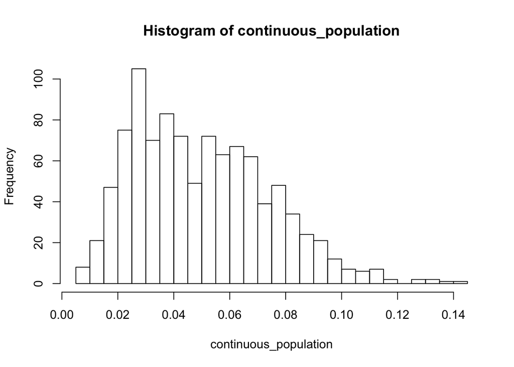

```r
#continuous_population <- c(rnorm(n = 500, mean = 0.5, sd = .015), rnorm(n = 500, mean = .6, sd = .015))
continuous_population <- c(rbeta(n = 500, 5, 150), rbeta(n = 500, 10, 145))
#continuous_population <- rbeta(n = 1000, 500, 10)
continuous_population <- continuous_population - mean(continuous_population) + .05
hist(continuous_population, breaks = 30)
```

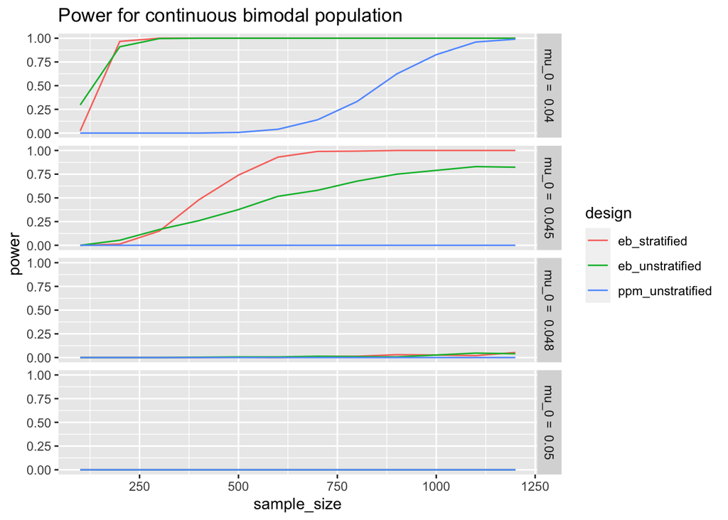

```r
#continuous_population <- c(c(rep(1,100), rep(0,400)), c(rep(1,400), rep(0,100)))
continuous_population <- continuous_population * 5

B <- 300
n_grid <- seq(100, 1200, by = 100)
n_grid <- ceiling(n_grid) - ceiling(n_grid) %% 2
mu_0_grid <- c(.04, .045, .048, .05) * 5
power_ppm_unstrat <- matrix(NA, nrow = length(n_grid), ncol = length(true_mean))
power_eb_unstrat <- matrix(NA, nrow = length(n_grid), ncol = length(mu_0_grid))
power_eb_strat <- matrix(NA, nrow = length(n_grid), ncol = length(mu_0_grid))
for(i in 1:length(n_grid)){
  for(j in 1:length(mu_0_grid)){
    replicates_ppm_unstrat <- replicate(n = B, beta_binomial_ppm(population = sample(continuous_population, size = n_grid[i], replace = TRUE), mu_0 = mu_0_grid[j], prior_alpha = 1, prior_beta = 1, last = TRUE))
    replicates_eb_unstrat <-  replicate(n = B, get_stratified_pvalue(population = continuous_population, strata = rep(1,1000), mu_0 = mu_0_grid[j], n = n_grid[i], method = "empirical_bernstein"))
    replicates_eb_strat <- replicate(n = B, get_stratified_pvalue(population = continuous_population, strata = c(rep(1,500), rep(2, 500)), mu_0 = mu_0_grid[j], n = c(n_grid[i]/2,n_grid[i]/2), method = "empirical_bernstein"))
    power_ppm_unstrat[i,j] <- mean(replicates_ppm_unstrat < .05)
    power_eb_unstrat[i,j] <- mean(replicates_eb_unstrat < .05)
    power_eb_strat[i,j] <- mean(replicates_eb_strat < .05)
  }
}
colnames(power_ppm_unstrat) <- paste("mu_0_", mu_0_grid, sep = "")
colnames(power_eb_strat) <- paste("mu_0_", mu_0_grid, sep = "")
colnames(power_eb_unstrat) <- paste("mu_0_", mu_0_grid, sep = "")

power_frame <- data.frame("power_eb_stratified" = power_eb_strat, "power_eb_unstratified" = power_eb_unstrat, "power_ppm_unstratified" = power_ppm_unstrat, "sample_size" = n_grid) %>%
  pivot_longer(cols = starts_with("power"), names_to = "design", values_to = "power", names_prefix = "power_") %>%
  separate(design, into = c("design","mu_0"), sep = ".mu_0_") %>%
  #separate(design, into = c("martingale", "design"), sep = "_") %>%
  mutate(mu_0 = paste("mu_0 = ", as.numeric(mu_0)/5))

ggplot(power_frame, aes(x = sample_size, y = power, color = design)) +
  ggtitle("Power for continuous bimodal population") +
  geom_line() +
  facet_grid(mu_0 ~ .)
```

### Highly stratified populations

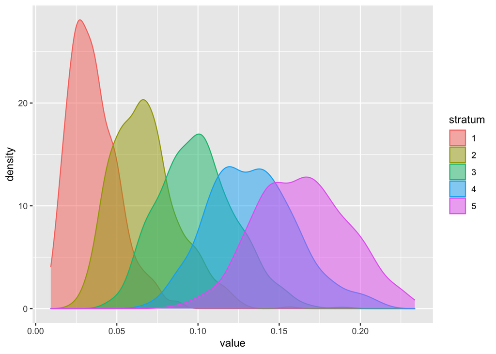

```r
highly_stratified_population <- c(rbeta(n = 500, 5, 150), rbeta(n = 500, 10, 145), rbeta(n = 500, 15, 140), rbeta(n = 500, 20, 135), rbeta(n = 500, 25, 130))
highly_stratified_population <- highly_stratified_population - mean(highly_stratified_population) + 0.1
#this population is somewhat like soil carbon though not bounded in [0,20]
ggplot(data.frame(value = highly_stratified_population) %>% mutate(stratum = as.factor(rep(1:5, each = 500))), aes(value, fill = stratum, color = stratum)) + geom_density(alpha = .5)
```

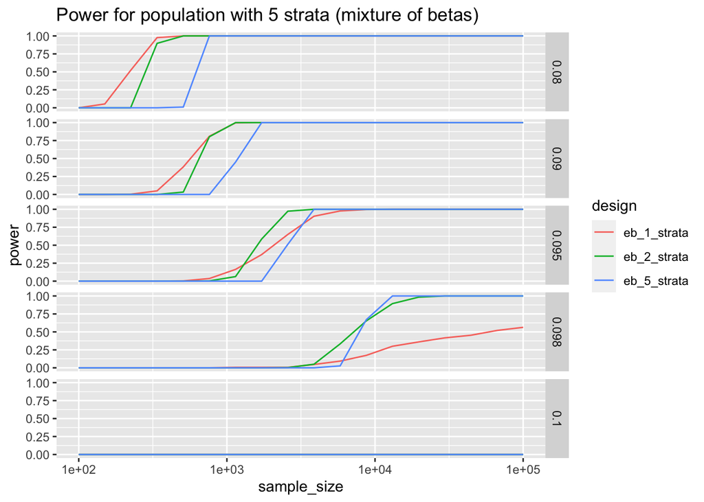

```r
B <- 300
n_grid <- round(10^seq(2, 5, length.out = 18))
n_grid <- ceiling(n_grid) - ceiling(n_grid) %% 2
mu_0_grid <- c(.08, .09, .095, .098, .1)
power_eb_1_strat <- matrix(NA, nrow = length(n_grid), ncol = length(mu_0_grid))
power_eb_2_strat <- matrix(NA, nrow = length(n_grid), ncol = length(mu_0_grid))
power_eb_5_strat <- matrix(NA, nrow = length(n_grid), ncol = length(mu_0_grid))
for(i in 1:length(n_grid)){
  for(j in 1:length(mu_0_grid)){

    replicates_eb_1_strat <- replicate(n = B, get_stratified_pvalue(population = highly_stratified_population, strata = rep(1,2500), mu_0 = mu_0_grid[j], n = n_grid[i], method = "empirical_bernstein"))
    replicates_eb_2_strat <- replicate(n = B, get_stratified_pvalue(population = highly_stratified_population, strata = c(rep(1,1250), rep(2,1250)), mu_0 = mu_0_grid[j], n = round(rep(n_grid[i]/2,2)), method = "empirical_bernstein"))
    replicates_eb_5_strat <- replicate(n = B, get_stratified_pvalue(population = highly_stratified_population, strata = c(rep(1,500), rep(2, 500), rep(3, 500), rep(4, 500), rep(5, 500)), mu_0 = mu_0_grid[j], n = round(rep(n_grid[i]/5,5)), method = "empirical_bernstein"))
    power_eb_1_strat[i,j] <- mean(replicates_eb_1_strat < .05)
    power_eb_2_strat[i,j] <- mean(replicates_eb_2_strat < .05)
    power_eb_5_strat[i,j] <- mean(replicates_eb_5_strat < .05)
  }
}
colnames(power_eb_1_strat) <- paste("mu_0_", mu_0_grid, sep = "")
colnames(power_eb_2_strat) <- paste("mu_0_", mu_0_grid, sep = "")
colnames(power_eb_5_strat) <- paste("mu_0_", mu_0_grid, sep = "")

power_frame <- data.frame("power_eb_1_strata" = power_eb_1_strat, "power_eb_2_strata" = power_eb_2_strat, "power_eb_5_strata" = power_eb_5_strat, "sample_size" = n_grid) %>%
  pivot_longer(cols = starts_with("power"), names_to = "design", values_to = "power", names_prefix = "power_") %>%
  separate(design, into = c("design","mu_0"), sep = ".mu_0_") %>%
  #separate(design, into = c("martingale", "design"), sep = "_") %>%
  mutate(mu_0 = as.numeric(mu_0))

ggplot(power_frame, aes(x = sample_size, y = power, color = design)) +
  ggtitle("Power for population with 5 strata (mixture of betas)") +
  geom_line() +
  scale_x_log10() +
  facet_grid(mu_0 ~ .)
```